# MMG 434 Bioinformatics Day 3

Matt Schnizlein

February 24, 2023

# Objectives

1. Develop greater familiarity with analyzing data using R
2. Learn best practices for stream-lining analysis
3. Visualize and interpret results from the Biolog ECOplate experiment

# At the start of lab:

## Pulling in packages

#### “Library” the following packages to make them available to us. You may need to install them using the `install.packages()` function.

```r
library(data.table)
library(ggplot2)
library(mdthemes)
library(dplyr)
```

#### We will also want to create a couple of unique functions that I have found useful in my own data analyses

```r
# This grabs n characters from the RIGHT side of a character variable
substrRight <- function(x, n){
  substr(x, nchar(x)-n+1, nchar(x))
}
# This grabs n characters from the LEFT side of a character variable
substrLeft <- function(x, n){
  substr(x, 1, n)
}
# This works just similar to %in% but selects what is NOT %in% instead
'%!in%'<-function(x,y)!('%in%'(x,y))
```

## Downloading your data

#### This will create the URLs and destination paths (i.e., the place you want to put your file) for the data

```r
name_final<-c("ECOplate_590_T24_G1.csv","ECOplate_590_T24_G2.csv","ECOplate_590_T24_G3.csv","ECOplate_590_T24_G4.csv","ECOplate_590_T24_G5.csv","ECOplate_590_T24_G6.csv","ECOplate_590_T48_G1.csv","ECOplate_590_T48_G2.csv","ECOplate_590_T48_G3.csv","ECOplate_590_T48_G4.csv","ECOplate_590_T48_G5.csv","ECOplate_590_T48_G6.csv","ECOplate_590_T72_G1.csv","ECOplate_590_T72_G2.csv","ECOplate_590_T72_G3.csv","ECOplate_590_T72_G4.csv","ECOplate_590_T72_G5.csv","/ECOplate_590_T72_G6.csv","ecoplate_carbonsource_template_key.csv","mmg434_SS23_aqpcr_ALLdatafiles.csv")

urls<-paste0("https://raw.githubusercontent.com/mschnizlein/mmg434_bioinformatics/main/data_bioinf_mmg434_SS23/",name_final) # creates URLs to datafiles

destinations<-paste0("data/",name_final) # creates destinations for datafiles
```

#### The “for” loop will iteratively pair our URLs and destinations to pull them from my GitHub repository

- `for (i in 1:20)` indicates that i will be equal to a series of numbers from 1 to 20 in the loop
- Anytime an `i` appears in the functions placed within the loop, it will substitute the currently selected number

#### Test out what the result will be by:

1. setting i to a particular number (i.e.,`i <- 1`) and then
2. testing out the code within the `for` loop (i.e., just enter the `download.file(urls[i],destfile = destinations[i])` part)

```r
for (i in 1:20){
  download.file(urls[i],destfile = destinations[i])
}
```

# Day 3 Data analysis

## Reading in our data

#### all 24 hour and most 48 hour timepoints are in a wide format, all 72 hours timepoints are in a long format)

- take a look at each style to get a sense of how information is being communicated
- each data file is a optical density reading for a particular group (i.e., 1 to 6) and timepoint (i.e., 24, 48 and 72 hrs)

```r
# Group 1
g1_t24<-as.data.frame(read.csv(file = "data/ECOplate_590_T24_G1.csv",header = TRUE))
g1_t48<-as.data.frame(read.csv(file = "data/ECOplate_590_T48_G1.csv",header = TRUE)) # long format
g1_t72<-as.data.frame(read.csv(file = "data/ECOplate_590_T72_G1.csv",header = TRUE))

# Group 2
g2_t24<-as.data.frame(read.csv(file = "data/ECOplate_590_T24_G2.csv",header = TRUE))
g2_t48<-as.data.frame(read.csv(file = "data/ECOplate_590_T48_G2.csv",header = TRUE))
g2_t72<-as.data.frame(read.csv(file = "data/ECOplate_590_T72_G2.csv",header = TRUE))

# Group 3
g3_t24<-as.data.frame(read.csv(file = "data/ECOplate_590_T24_G3.csv",header = TRUE))
g3_t48<-as.data.frame(read.csv(file = "data/ECOplate_590_T48_G3.csv",header = TRUE))
g3_t72<-as.data.frame(read.csv(file = "data/ECOplate_590_T72_G3.csv",header = TRUE))

# Group 4
g4_t24<-as.data.frame(read.csv(file = "data/ECOplate_590_T24_G4.csv",header = TRUE))
g4_t48<-as.data.frame(read.csv(file = "data/ECOplate_590_T48_G4.csv",header = TRUE))
g4_t72<-as.data.frame(read.csv(file = "data/ECOplate_590_T72_G4.csv",header = TRUE))

# Group 5
g5_t24<-as.data.frame(read.csv(file = "data/ECOplate_590_T24_G5.csv",header = TRUE))
g5_t48<-as.data.frame(read.csv(file = "data/ECOplate_590_T48_G5.csv",header = TRUE))
g5_t72<-as.data.frame(read.csv(file = "data/ECOplate_590_T72_G5.csv",header = TRUE))

# Group 6
g6_t24<-as.data.frame(read.csv(file = "data/ECOplate_590_T24_G5.csv",header = TRUE))
g6_t48<-as.data.frame(read.csv(file = "data/ECOplate_590_T48_G5.csv",header = TRUE))
g6_t72<-as.data.frame(read.csv(file = "data/ECOplate_590_T72_G5.csv",header = TRUE))

# A key to map carbon sources to particular wells
key<-read.csv(file="data/ecoplate_carbonsource_template_key.csv",header=TRUE)
```

#### The last file is a key that we’ll use to understand the optical densities later on

- See the product guide on D2L for how the ECOplate template I used to create the key

#### Now that our data is read into the R environment, lets put them all in lists so we can manipulate them all simulaneously.

- It’s possible to do this file by file as well, but it would also significantly increase the amount of lines of code we would need (i.e., this is more *elegant*)
- Since we have two different data formats we need to treat them differently before it’s possible to join them together

```r
df_list_wide<-list("g1_t24"=g1_t24,"g2_t24"=g2_t24,"g3_t24"=g3_t24,"g4_t24"=g4_t24,"g5_t24"=g5_t24,"g6_t24"=g6_t24,"g2_t48"=g2_t48,"g3_t48"=g3_t48,"g4_t48"=g4_t48,"g5_t48"=g5_t48,"g6_t48"=g6_t48)

str(df_list_wide)
```

#### After creating a list of the wide format, let’s convert them to long format using the `melt()` function

```r
df_list_wide.m<-lapply(df_list_wide, function(x) melt(x, id.vars =  "rowID"))
```

#### - How did that change the data’s format? (use `str()` to take a look)

#### - Does it look like the format of the 72 hour data frames yet?

#### Here we use a `for` loop to iteratively perform a series of commands

- Consider this phrase `df_list_wide.m[[i]]`. Based on what you know of lists, what will this command give you as you cycle through each time?
- What about `df_list_wide.m[[i]][,1]`?

```r
for (i in 1:11){
  df_list_wide.m[[i]][,1]<-paste0(df_list_wide.m[[i]][,1],gsub("X","",df_list_wide.m[[i]][,2])) # combining row name with column number with `paste0`
  df_list_wide.m[[i]]<-df_list_wide.m[[i]][c(1,3)]
  df_list_wide.m[i]<-lapply(df_list_wide.m[i], function(x) setnames(x,c("wellID",paste0("time_",substrRight(names(df_list_wide.m[i]),2))))) # using `substrRight` we are renaming each of the columns in the data frames wellID, and then time_XX. XX will be the right-most two characters of the dataframe name which are the time point in hours); we also use `setnames` to change the column names

} # note that the for loop doesn't end until down here
```

#### Do we have the correct data format now?

#### Let’s make a list of the long format data

```r
df_list_long<-list("g1_t48"=g1_t48,"g1_t72"=g1_t72,"g2_t72"=g2_t72,"g3_t72"=g3_t72,"g4_t72"=g4_t72,"g5_t72"=g5_t72,"g6_t72"=g6_t72)
```

#### And run a `for` loop to relabel the columns in these data frames as well

```r
for (i in 1:7){
  df_list_long[i]<-lapply(df_list_long[i], function(x) setnames(x,c("wellID",paste0("time_",substrRight(names(df_list_long[i]),2)))))
}
```

#### Success! Our data can now be combined!!

```r
df_list.f<-c(df_list_wide.m,df_list_long)

str(df_list.f)
```

#### Let’s add in our carbohydrate information before subsetting it based on groups using the `merge()` function

```r
df_list.f<-lapply(df_list.f, function(x) merge(x, key, by.all = "wellID", sort=FALSE))

str(df_list.f)
```

## Subsetting by Group

#### In this section we will pull out each individual group data into it’s own dataframe and prepare it for plotting

```r
# Group 1's data
g1_list<-c(df_list.f["g1_t24"],df_list.f["g1_t48"],df_list.f["g1_t72"]) # making a list of all of group 1's timepoints

g1_data<-Reduce(function(x,y) merge(x, y, all= TRUE), g1_list) # merging these together into one data frame
```

#### Take a look at the new data frame using a few different commands we have learned (i.e., `head()`, `tail()`, `str()`, `colnames()`)

#### Now that we have a useable data frame, let’s select carbon sources where we had a positive growth result (i.e., there was enough to cause reduction of the tetrazolium dye in the Biolog plates)

- I chose an arbitrary cut-off of a 0.2 OD increase from the 24 hr time point
- In this command I use *conditional formatting* to select for OD values with that increase and identify the carbon sources where that occurred

```r
g1_carbon<-unique(g1_data[g1_data$time_72 >= (g1_data$time_24+0.2),]$carbon_source)

print(g1_carbon)
```

```
##  [1] "b-methyl-d-glucoside"     "l-arginine"
##  [3] "d-galacturonic_acid"      "l-asparagine"
##  [5] "d-mannitol"               "l-serine"
##  [7] "n-acetyl-d-glucosamine"   "glycyl-l-glutamic_acid"
##  [9] "glycogen"                 "glucose-1-phosphate"
## [11] "d-malic_acid"             "d,l-a-glycerol-phosphate"
```

#### Let’s subset our data to only include the carbon sources we just identified

```r
g1_pos<-g1_data[g1_data$carbon_source %in% g1_carbon,]
```

#### Finally, we will convert our data frame into a long format, since that’s what ggplot prefers

- We can also grab the right 2 characters of the variable column in our data frame using `substrRight` since that will be time; we can then turn those into numbers with `as.numeric`

```r
g1_pos.m<-melt(g1_pos, id.vars=c("wellID","carbon_source"))
g1_pos.m$variable<-as.numeric(substrRight(as.character(g1_pos.m$variable),2))
```

#### Enter the following commands to create dataframes for the remaining 5 groups (**NOTE:** all groups should perform these commands)

#### **Group 2**

```r
g2_list<-c(df_list.f["g2_t24"],df_list.f["g2_t48"],df_list.f["g2_t72"])
g2_data<-Reduce(function(x,y) merge(x, y, all= TRUE), g2_list)
g2_carbon<-unique(g2_data[g2_data$time_72 >= (g2_data$time_24+0.2),]$carbon_source)
g2_pos<-g2_data[g2_data$carbon_source %in% g2_carbon,]
g2_pos.m<-melt(g2_pos, id=c("wellID","carbon_source"))
g2_pos.m$variable<-as.numeric(substrRight(as.character(g2_pos.m$variable),2))
```

#### **Group 3**

```r
g3_list<-c(df_list.f["g3_t24"],df_list.f["g3_t48"],df_list.f["g3_t72"])
g3_data<-Reduce(function(x,y) merge(x, y, all= TRUE), g3_list)
g3_carbon<-unique(g3_data[g3_data$time_72 >= (g3_data$time_24+0.2),]$carbon_source)
g3_pos<-g3_data[g3_data$carbon_source %in% g3_carbon,]
g3_pos.m<-melt(g3_pos, id=c("wellID","carbon_source"))
g3_pos.m$variable<-as.numeric(substrRight(as.character(g3_pos.m$variable),2))
```

#### **Group 4**

```r
g4_list<-c(df_list.f["g4_t24"],df_list.f["g4_t48"],df_list.f["g4_t72"])
g4_data<-Reduce(function(x,y) merge(x, y, all= TRUE), g4_list)
g4_carbon<-unique(g4_data[g4_data$time_72 >= (g4_data$time_24+0.2),]$carbon_source)
g4_pos<-g4_data[g4_data$carbon_source %in% g4_carbon,]
g4_pos.m<-melt(g4_pos, id=c("wellID","carbon_source"))
g4_pos.m$variable<-as.numeric(substrRight(as.character(g4_pos.m$variable),2))
```

#### **Group 5**

```r
g5_list<-c(df_list.f["g5_t24"],df_list.f["g5_t48"],df_list.f["g5_t72"])
g5_data<-Reduce(function(x,y) merge(x, y, all= TRUE), g5_list)
g5_carbon<-unique(g5_data[g5_data$time_72 >= (g5_data$time_24+0.2),]$carbon_source)
g5_pos<-g5_data[g5_data$carbon_source %in% g5_carbon,]
g5_pos.m<-melt(g5_pos, id=c("wellID","carbon_source"))
g5_pos.m$variable<-as.numeric(substrRight(as.character(g5_pos.m$variable),2))
```

#### **Group 6**

```r
g6_list<-c(df_list.f["g6_t24"],df_list.f["g6_t48"],df_list.f["g6_t72"])
g6_data<-Reduce(function(x,y) merge(x, y, all= TRUE), g6_list)
g6_carbon<-unique(g6_data[g6_data$time_72 >= (g6_data$time_24+0.2),]$carbon_source)
g6_pos<-g6_data[g6_data$carbon_source %in% g6_carbon,]
g6_pos.m<-melt(g6_pos, id=c("wellID","carbon_source"))
g6_pos.m$variable<-as.numeric(substrRight(as.character(g6_pos.m$variable),2))
```

### For each individual group, choose the command under the appropriate heading to make a plot for your data

**Group 1**

```r
data_forplot<-g1_pos.m
```

**Group 2**

```r
data_forplot<-g2_pos.m
```

**Group 3**

```r
data_forplot<-g3_pos.m
```

**Group 4**

```r
data_forplot<-g4_pos.m
```

**Group 4**

```r
data_forplot<-g4_pos.m
```

**Group 5**

```r
data_forplot<-g5_pos.m
```

**Group 6**

```r
data_forplot<-g6_pos.m
```

## Plotting our data (at last!)

#### Let’s create a theme that we can call in each plot

- Here is where we change things like font size, axis line colors, etc.)
- This will also streamline each plot by reducing redundant code
- Take a look at each line within the `theme()` function, after we make plots in a second, revisit each of these and delete particular lines and see how they affect your plot

```r
my_theme<-theme_bw() + theme(axis.line=element_line(color="black"),
                             panel.grid.major = element_blank(),
                             panel.grid.minor = element_blank(),
                             panel.border = element_blank(),
                             panel.background = element_blank(),
                             text=element_text(size = 12))
```

#### Now that we have a theme, let’s create our plot:

- Remember, ggplot uses layers, so we will build those layers on top of each other to gradually fill out the plot we want

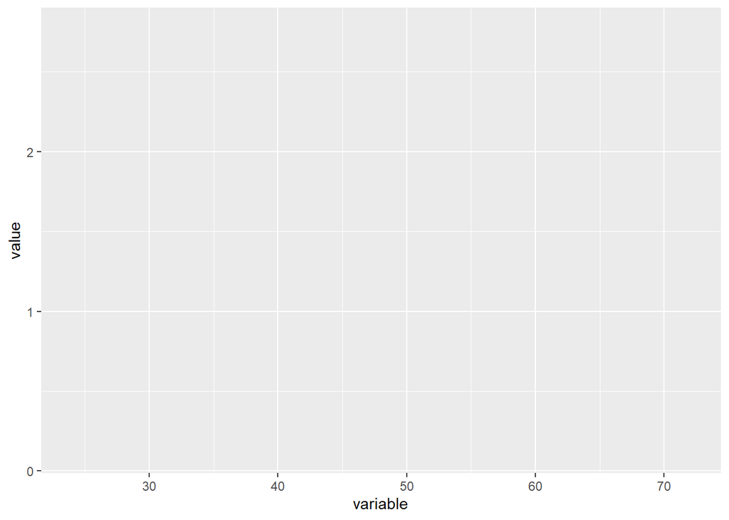

```r
# Let's create an empty plot
growth_all.p<-ggplot(data_forplot,aes(x=variable,y=value,color=carbon_source,group=carbon_source,fill=carbon_source))

plot(growth_all.p)
```

#### Adding our data points with `geom_jitter()`

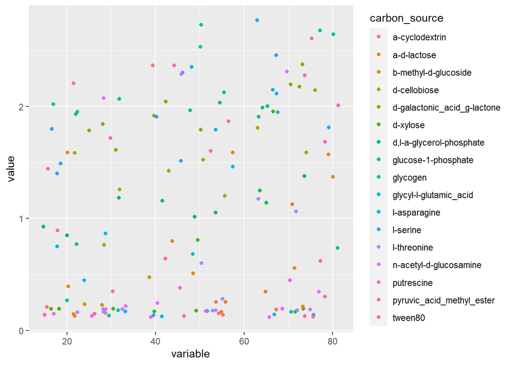

```r
growth_all.p<-ggplot(data_forplot,aes(x=variable,y=value,color=carbon_source,group=carbon_source,fill=carbon_source))+
  geom_jitter()

plot(growth_all.p)
```

#### Those data points are chaotic, we could either

- plot with `geom_point()` instead
- add a `width` parameter inside `geom_jitter()`

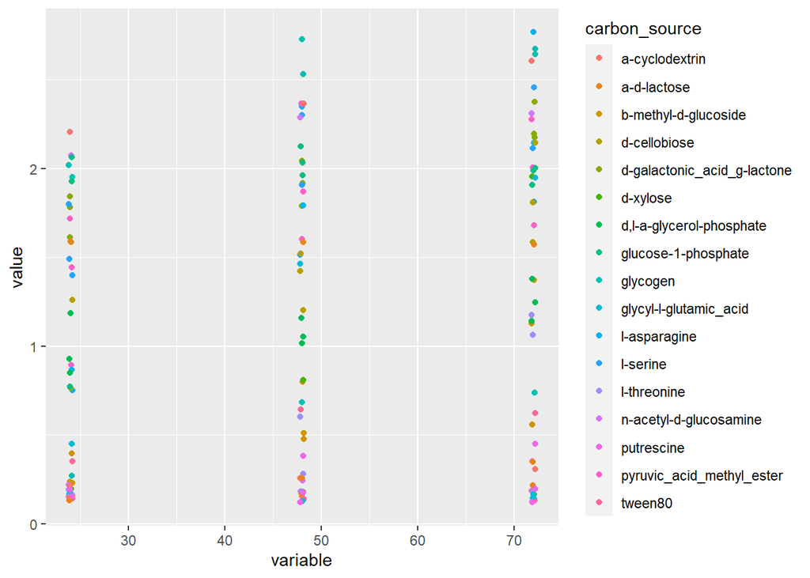

```r
growth_all.p<-ggplot(data_forplot,aes(x=variable,y=value,color=carbon_source,group=carbon_source,fill=carbon_source))+
  geom_jitter(width=0.2)

plot(growth_all.p) # are data points are less spread out but not completely overlapping
```

#### With all of the data points though, it is difficult to see trends. So, let’s add a trend line with `stat_summary()`

- `stat_summary` uses the mean our data at each time point

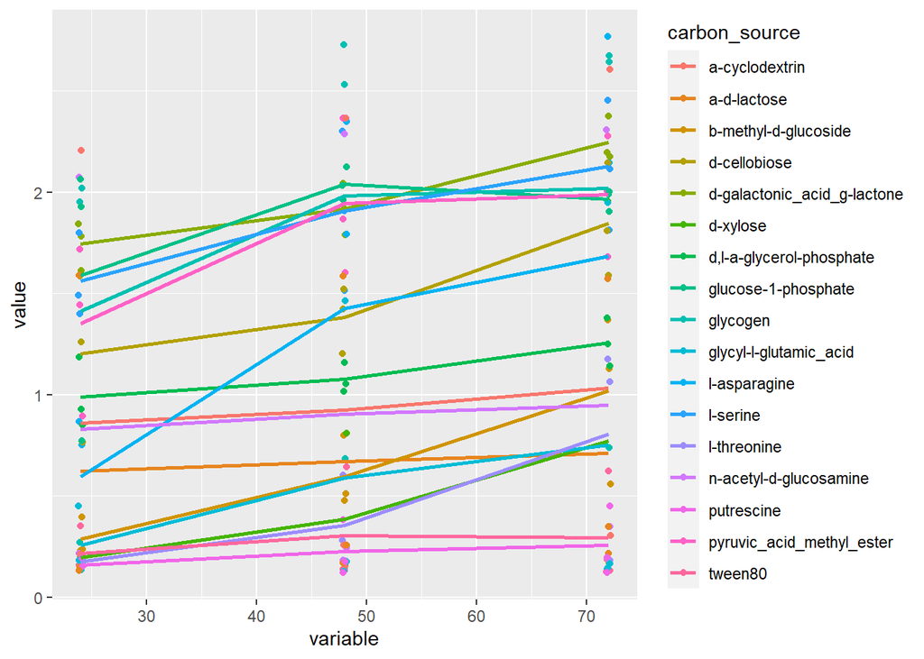

```r
growth_all.p<-ggplot(data_forplot,aes(x=variable,y=value,color=carbon_source,group=carbon_source,fill=carbon_source))+geom_jitter(width=0.2)+
  stat_summary(fun=mean, geom="line", size=1)

plot(growth_all.p)
```

#### Using a variant of `stat_summary()` we can add the mean standard error (`mean_se`) in a semi-transparent ribbon along our lines

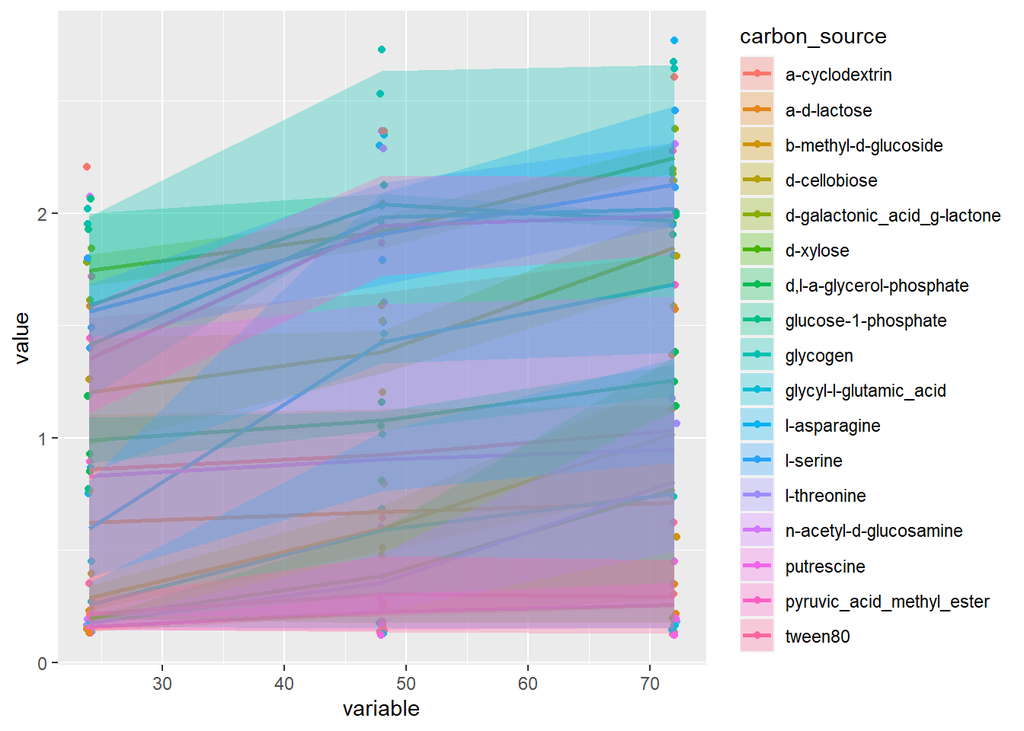

```r
growth_all.p<-ggplot(data_forplot,aes(x=variable,y=value,color=carbon_source,group=carbon_source,fill=carbon_source))+geom_jitter(width=0.2)+
  stat_summary(fun=mean, geom="line", size=1)+
  stat_summary(fun.data = mean_se,geom="ribbon",color="transparent",alpha=0.3)

plot(growth_all.p)
```

#### That’s pretty messy, so let’s plot each carbon source individually with `facet_wrap()`

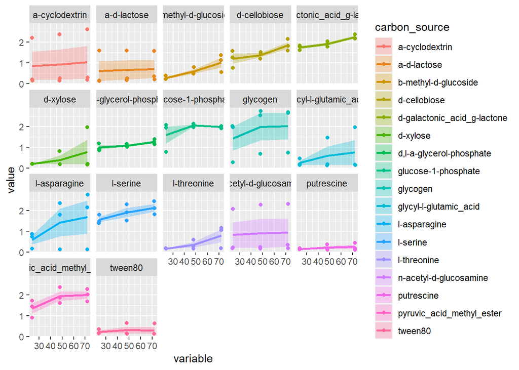

```r
growth_all.p<-ggplot(data_forplot,aes(x=variable,y=value,color=carbon_source,group=carbon_source,fill=carbon_source))+geom_jitter(width=0.2)+
  stat_summary(fun=mean, geom="line", size=1)+
  stat_summary(fun.data = mean_se,geom="ribbon",color="transparent",alpha=0.3)+
  facet_wrap(~carbon_source)

plot(growth_all.p)
```

#### Last but not least, let’s polish up our plot a little by adding better axis labels

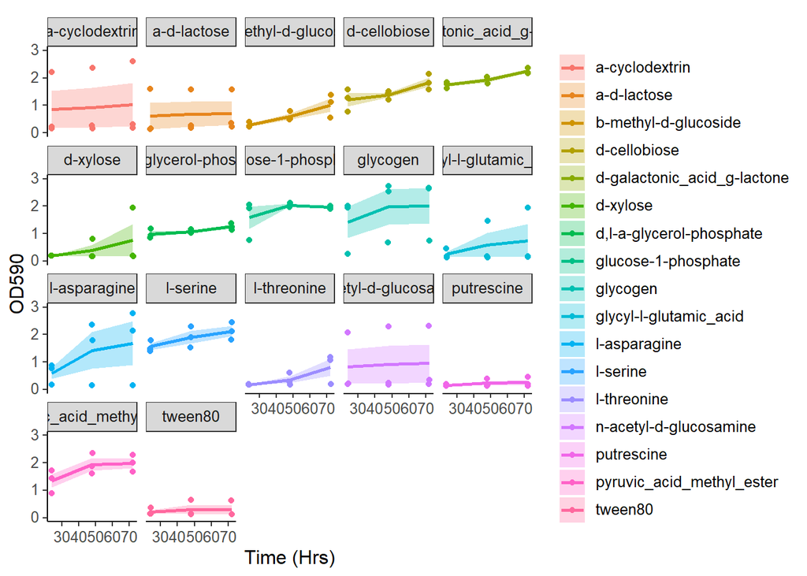

```r
growth_all.p<-ggplot(data_forplot,aes(x=variable,y=value,color=carbon_source,group=carbon_source,fill=carbon_source))+geom_jitter(width=0.2)+
  stat_summary(fun=mean, geom="line", size=1)+
  stat_summary(fun.data = mean_se, geom="ribbon", color="transparent", alpha=0.3)+
  ylim(0,3)+
  scale_fill_discrete()+ # this sets color parameters for the mean_se ribbon
  scale_color_discrete()+ # this sets color parameters for the lines
  as_md_theme(my_theme)+ # this applies our theme from above to the plot
  ylab("OD590") + xlab("Time (Hrs)") + # here are our axis labels
  labs(color="",fill="") + # these would label our legend
  ggtitle("")+ # this would label the plot itself
  facet_wrap(~carbon_source)

plot(growth_all.p)
```

#### We finally get an overall look at our positive hits

- Are there some carbon sources that support more growth than others?
- Are each of the three replicates consistent?

### How many positive carbon sources were there across groups?

```r
pos_list<-list(g1_pos.m,g2_pos.m,g3_pos.m,g4_pos.m,g5_pos.m,g6_pos.m)
```

#### this command is getting the number of rows for each list of positive hits and then dividing by the number of time points (remember it’s a long format data frame) as well as the number of replicates, which was three

```r
pos_num<-lapply(pos_list, function(x) (nrow(x)/(3*3)))
```

#### Let’s make a plot and see how many hits there were by group

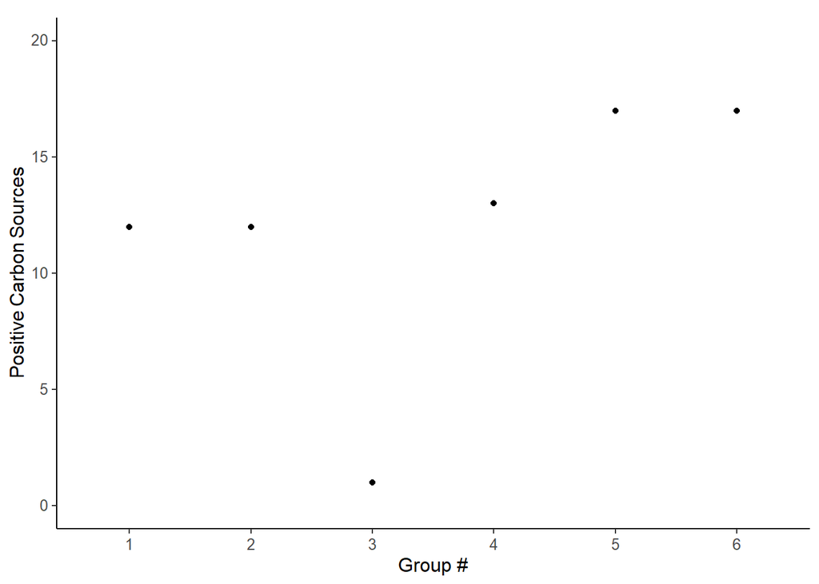

```r
pos.p<-ggplot(data.frame(sapply(pos_num,c)), aes(y=sapply.pos_num..c., x=rownames(data.frame(sapply(pos_num,c)))))+geom_point()+
  ylim(0,20)+
  as_md_theme(my_theme)+
  ylab("Positive Carbon Sources") + xlab("Group #") + labs() +
  ggtitle("")

plot(pos.p)
```

## Brainstorm with your group

1. Can you add an informative title to your carbohydrate plot?
2. How would you create a custom color palette that has better contrast? (Hint: use `scale_color_manual()` and `scale_fill_manual()`; and don’t be forget to make use of R documentation using `?` as well as Google)
- These two websites offer some great resources for mixing and matching colors:
  - https://davidmathlogic.com/colorblind/#%23D81B60-%231E88E5-%23FFC107-%23004D40
  - https://colordesigner.io/gradient-generator
3. Instead of one large plot showing every positive hit, can you make a plot with only one sugar shown?
4. What do your negative hits look like? Did the water control show any dye reduction?
5. Are there other plots that might be interesting to evaluate your data (check out the ggplot cheat sheet for ideas)?
6. Can you add more relevant group labels on the x-axis of the positive hit summary chart (i.e., animal type)? Use the `scale_x_discrete()` parameter in ggplot2, you can specific the order using `breaks = c()` and labels with `labels = c()`
   - Group 1: Goat
   - Group 2: Dog
   - Group 3: Cat
   - Group 4: Horse
   - Group 5: Dog
   - Group 6: Dog